# homework2

Zsombor Hegedus

2021 április 6

## Hotdog or not hotdog

In this section I am going to present my solution for an image classification task in which I will build a model to identify hotdogs. First of all I stripped out randomly 50 hotdog and non-hotdogs to use that as validation (an R script in my repo has the code that does this). After that I loaded up images in 150x150 size with keras's inbuilt data generator functions.

### Baseline model

I first I used a convolutional network very similar to what was available in the course repo. As seen below it has thee 2d convolutional layers with max poolingg, then a dropout layer wuth flattener, and two dense layers in the end, where the last one - the output layer - is with sigmoid activation function. The output layer has only one node in the end, since all we care about is whether the image is a hotdog or not.

Model: "sequential" ________________________________________________________________________________ Layer (type) Output Shape Param #  
================================================================================ conv2d_2 (Conv2D) (None, 148, 148, 32) 896  
________________________________________________________________________________ max_pooling2d_2 (MaxPooling2D) (None, 74, 74, 32) 0  
________________________________________________________________________________ conv2d_1 (Conv2D) (None, 72, 72, 16) 4624  
________________________________________________________________________________ max_pooling2d_1 (MaxPooling2D) (None, 36, 36, 16) 0  
________________________________________________________________________________ conv2d (Conv2D) (None, 34, 34, 16) 2320  
________________________________________________________________________________ max_pooling2d (MaxPooling2D) (None, 17, 17, 16) 0  
________________________________________________________________________________ dropout (Dropout) (None, 17, 17, 16) 0  
________________________________________________________________________________ flatten (Flatten) (None, 4624) 0  
________________________________________________________________________________ dense_1 (Dense) (None, 8) 37000  
________________________________________________________________________________ dense (Dense) (None, 1) 9  
================================================================================ Total params: 44,849 Trainable params: 44,849 Non-trainable params: 0 ________________________________________________________________________________

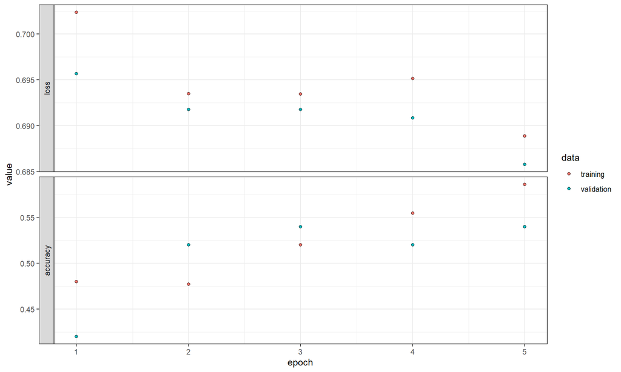

I first experimented with image augmentation. For that I did a few preprocessing steps in the train generator functions - I shifted the images and zoomed in on them as well. The layers were the same as in the earlier example, so let's see how accuracy faired.

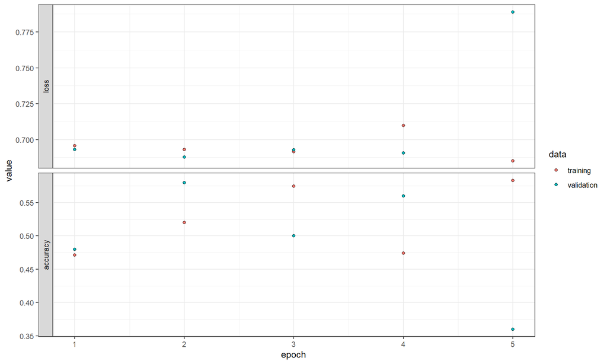

Lastly I tried out tansfer learning - the idea of transfer learning is to use pre-trained models which have been fed with hundreds of thousands of images and use the knowedge gained by their learning to predict for my particular problem as well. I will use the ImageNet image database that is available for free and has processed a huge amount of data already.

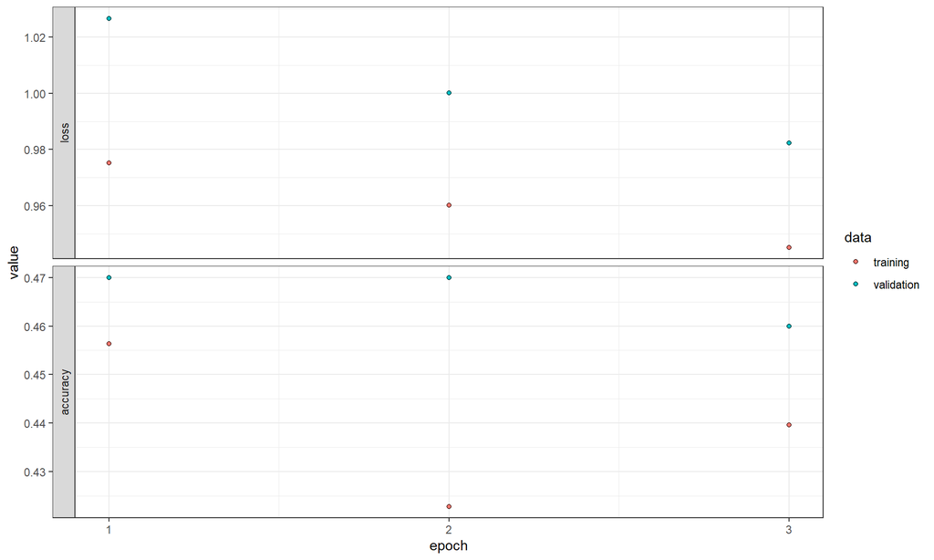

|  | Baseline model | Baseline model + Augmentation | Imagenet Transfer learning model |
| --- | --- | --- | --- |
| loss | 0.6925782 | 0.7329957 | 0.9621029 |
| accuracy | 0.5320000 | 0.5000000 | 0.4360000 |